# Data Science Midterm Assessment

Put Your Name Here

Due: October 17, 2017

## Instructions

This is an individual assignment. You may discuss how functions work with your classmates, but you cannot ask someone to debug/fix your code. You have to do that! Any failure to do so will lead to a 0 on this assignment and an Academic Honesty Violation.

Make all edits in this R Markdown Document. No code should appear in the knitted document. You should have one code block for each question. Upload this .Rmd (which should knit) to eLearn by the end of Tuesday, October 17. (I recommend working on tidying the data only when a question requires it. To make sure you can get back to working code. Use git and commit after you have answered a question. Questions probably shouldn’t be answered in the order they are written.)

## The Data

The schedule for next semester can be found at http://www2.loras.edu/admin/sprsched2.html. (Old versions can be found at http://www2.loras.edu/admin/fallsched.html and http://www2.loras.edu/admin/sprsched.html. These maybe useful for testing purposes for some things.)

## The Tasks

1. Import the data into R and tidy it up. (I recommend `read_fwf()` for import. `lead()` and `lag()` will be your friends for tidying. The [chapter on strings](http://r4ds.had.co.nz/strings.html) may also help.)

```r
Spring_Schedule <- read_fwf(file = "http://www2.loras.edu/admin/sprsched2.html", fwf_widths(c(3,5,6,7,5,4,5,36,10,15,8,6,6,30), c("MAX", "USED", "WTLST", "SYN", "DEPT", "CAT", "SEC", "TITLE", "CRED", "TIME", "DAY", "BLDG", "ROOM", "INSTRUCTOR")), skip = 5)
```

2. Create visualizations that summarize the following:
   1. Distribution of number of courses offered in each discipline.

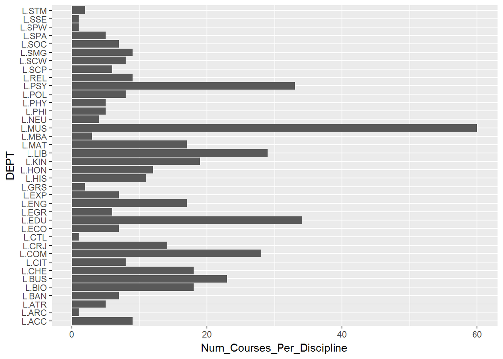

   ```r
   Spring_Schedule %>%

       group_by(DEPT) %>%

           filter(!is.na(DEPT)) %>%

               summarise(Num_Courses_Per_Discipline = n()) %>%

                   ggplot() + geom_col(mapping = aes(x = DEPT, y = Num_Courses_Per_Discipline)) + coord_flip()
   ```

   2. Distribution of level (100, 200, 300, 400, …) of courses.

[figure not shown]

   ```r
   Spring_Schedule %>%

   group_by(CAT) %>%

     filter(!is.na(CAT)) %>%

         summarise(Category_Count = n()) %>%

                 ggplot() + geom_col(mapping = aes(x = CAT, y = Category_Count)) + coord_flip()
   ```

   3. Distribution of level of course by discipline.

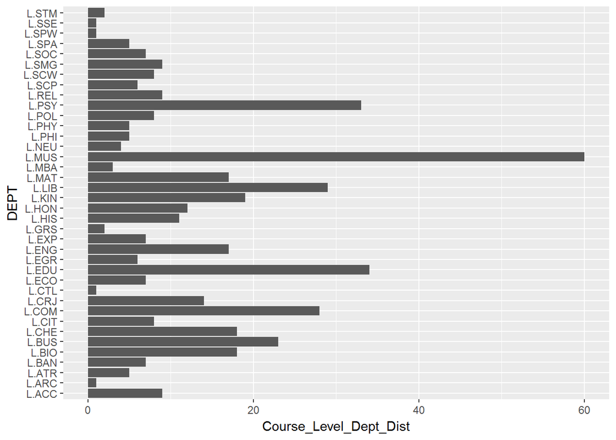

   ```r
      Spring_Schedule %>%

       group_by(DEPT, CAT) %>%

           filter(!is.na(DEPT) & !is.na(CAT)) %>%

               summarise(Course_Level_Dept_Dist = n()) %>%

                   ggplot() + geom_col(mapping = aes(x = DEPT, y = Course_Level_Dept_Dist)) + coord_flip()
   ```

   4. Distribution of start time of courses.

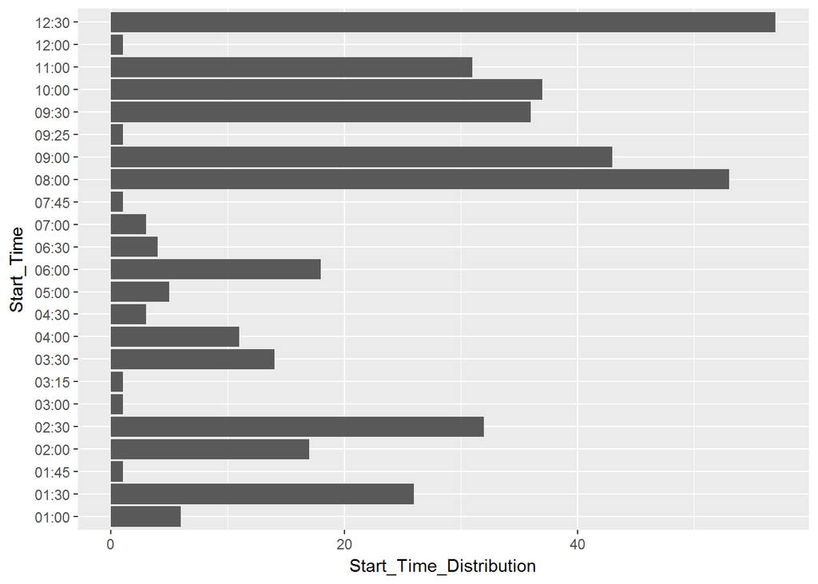

   ```r
   Spring_Schedule %>%

       separate(TIME, into = c("Start_Time", "End_Time"), sep = "-") %>%

           group_by(Start_Time) %>%

              filter(!is.na(Start_Time)) %>%

               filter(Start_Time != "Their Own Land" & Start_Time != "t. of Latin Ame" & Start_Time != "ronmental Bio" & Start_Time != "ports" & Start_Time != "ort" & Start_Time != "nmental Politic" & Start_Time != "minar" & Start_Time != "ir. Sustain." & Start_Time != "Greece & Rome" & Start_Time != "Film: Africa" & Start_Time != "e following date" & Start_Time != "dentity Am West" & Start_Time != "ature/Ireland" & Start_Time != "A" & Start_Time != "a" & Start_Time != "ental Politic" & Start_Time != ". Sustain." & Start_Time != "ure/Ireland" & Start_Time != "t" & Start_Time != "rts" & Start_Time != "reece & Rome" & Start_Time != "on:" & Start_Time != "of Latin Ame" & Start_Time != "ntity Am West" & Start_Time != "nmental Bio" & Start_Time != "nar" & Start_Time != "lm: Africa" & Start_Time != "heir Own Land" & Start_Time != "following dates:" & Start_Time != "CA"& Start_Time != "following dates") %>%

                 summarise(Start_Time_Distribution = n()) %>%

                     ggplot() + geom_col(mapping = aes(x = Start_Time, y = Start_Time_Distribution)) + coord_flip()
   ```

   5. Distribution of the duration of class meeting.

   ```r
   Spring_Schedule %>%

       separate(TIME, into = c("Start_Time", "End_Time"), sep = "-")
   ```

   ```
   ## # A tibble: 1,838 x 15
   ##      MAX  USED WTLST   SYN  DEPT   CAT   SEC                TITLE  CRED
   ##  * <int> <int> <chr> <int> <chr> <chr> <chr>                <chr> <chr>
   ##  1    25     0  <NA>  9154 L.ACC   228    01 Financial Accounting   3.0
   ##  2    NA    NA  <NA>    NA  <NA>  <NA>  <NA>      Jan 29 - May 17  <NA>
   ##  3    NA    NA  <NA>    NA  <NA>  <NA>  <NA>                 <NA>  <NA>
   ##  4    25     0  <NA>  9155 L.ACC   228    02 Financial Accounting   3.0
   ##  5    NA    NA  <NA>    NA  <NA>  <NA>  <NA>      Jan 29 - May 17  <NA>
   ##  6    NA    NA  <NA>    NA  <NA>  <NA>  <NA>                 <NA>  <NA>
   ##  7    25     0  <NA>  9156 L.ACC   228    03 Financial Accounting   3.0
   ##  8    NA    NA  <NA>    NA  <NA>  <NA>  <NA>      Jan 29 - May 17  <NA>
   ##  9    NA    NA  <NA>    NA  <NA>  <NA>  <NA>                 <NA>  <NA>
   ## 10    25     0  <NA>  9157 L.ACC   228    04 Financial Accounting   3.0
   ## # ... with 1,828 more rows, and 6 more variables: Start_Time <chr>,
   ## #   End_Time <chr>, DAY <chr>, BLDG <chr>, ROOM <chr>, INSTRUCTOR <chr>
   ```

   ```r
          # Duration = mutate("End_Time" - "Start_Time") Need to figure out how to convert chr time to numeric time

          # summarise()
   ```

   6. Distribution of start time of courses by discipline. (Only show the interesting ones.) I’m classifying the interesting ones as the computer science, math, and education disciplines since they are all parts of my majors and minors.

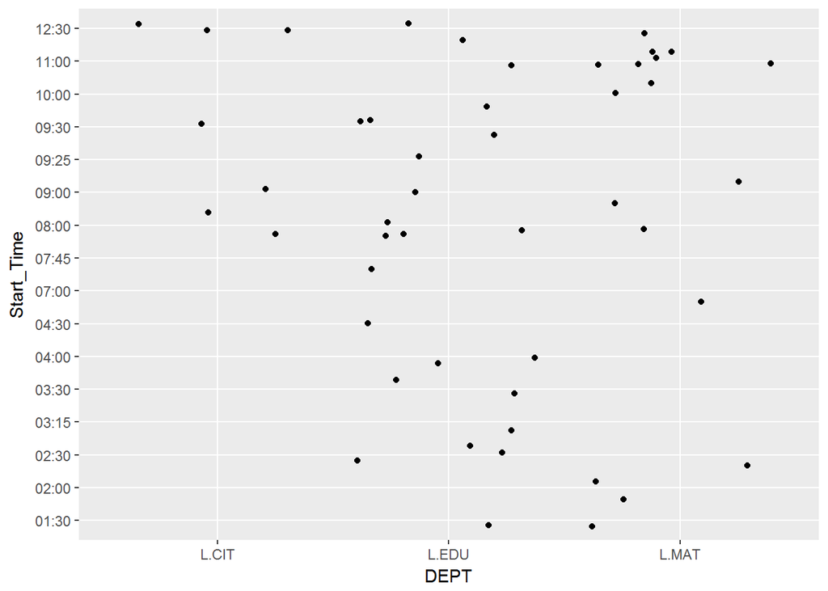

   ```r
   Spring_Schedule %>%

       group_by(TIME, DEPT) %>%

           separate(TIME, into = c("Start_Time", "End_Time"), sep = "-") %>%

               filter(!is.na(DEPT) & !is.na(Start_Time)) %>%

                 filter(DEPT == "L.MAT" | DEPT == "L.EDU" | DEPT == "L.CIT" & Start_Time != "A") %>%

                   ggplot() + geom_jitter(mapping = aes(x = DEPT, y = Start_Time))
   ```

   7. Distribution of the duration of class meeting by discipline.

   ```r
   # Spring_Schedule
   ```

   8. Distribution of building usage.

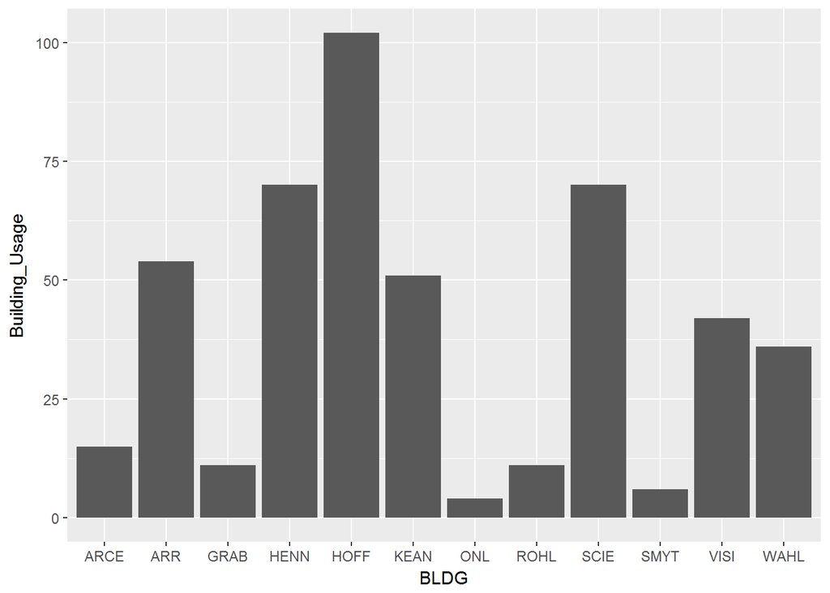

[output not shown]

```r
Spring_Schedule %>%

    group_by(BLDG) %>%

      filter(!is.na(BLDG)) %>%

          summarise(Building_Usage = n()) %>%

                  ggplot() + geom_col(mapping = aes(x = BLDG, y = Building_Usage))
```

3. Create blocks that show:
   1. All the courses that have space in them. (`MAX` > `USED`)

   ```r
   Spring_Schedule %>%

       filter(SYN, MAX > USED)
   ```

   ```
   ## # A tibble: 447 x 14
   ##      MAX  USED WTLST   SYN  DEPT   CAT   SEC                      TITLE
   ##    <int> <int> <chr> <int> <chr> <chr> <chr>                      <chr>
   ##  1    25     0  <NA>  9154 L.ACC   228    01       Financial Accounting
   ##  2    25     0  <NA>  9155 L.ACC   228    02       Financial Accounting
   ##  3    25     0  <NA>  9156 L.ACC   228    03       Financial Accounting
   ##  4    25     0  <NA>  9157 L.ACC   228    04       Financial Accounting
   ##  5    25     0  <NA>  9159 L.ACC   332    01 Intermed Financial Acct II
   ##  6    25     0  <NA>  9160 L.ACC   344    01        Adv Cost Accounting
   ##  7    25     0  <NA>  9161 L.ACC   352    01   Acct for Govt/Non-Profit
   ##  8    25     0  <NA>  9162 L.ACC   450    01                   Auditing
   ##  9    25     0  <NA>  9163 L.ACC   456    01      Federal Income Tax II
   ## 10    15     0  <NA>  9645 L.ARC   125    01     Characteristics of ASD
   ## # ... with 437 more rows, and 6 more variables: CRED <chr>, TIME <chr>,
   ## #   DAY <chr>, BLDG <chr>, ROOM <chr>, INSTRUCTOR <chr>
   ```

   2. All the courses that are `NOT OPEN TO FIRST YEAR STUDENTS`.

   Based off of the table below, there are 71 classes that are not open to freshman based off of what is stated in the TITLE column. Also all of the other cells are NA because of my TITLE consolidation of rows conondrum that I talk about below in e. and i. in further detail.

   ```r
   Spring_Schedule %>%

       group_by(TITLE) %>%

            filter(str_detect(TITLE, "NOT OPEN TO FIRST YEAR STUDENTS") | str_detect(TITLE, "SOPHOMORES only") | str_detect(TITLE, "JUNIORS Only") | str_detect(TITLE, "SENIORS ONLY") | str_detect(TITLE, "JUNIORS & SENIORS ONLY"))
   ```

   ```
   ## # A tibble: 71 x 14
   ## # Groups:   TITLE [5]
   ##      MAX  USED WTLST   SYN  DEPT   CAT   SEC
   ##    <int> <int> <chr> <int> <chr> <chr> <chr>
   ##  1    NA    NA  <NA>    NA  <NA>  <NA>  <NA>
   ##  2    NA    NA  <NA>    NA  <NA>  <NA>  <NA>
   ##  3    NA    NA  <NA>    NA  <NA>  <NA>  <NA>
   ##  4    NA    NA  <NA>    NA  <NA>  <NA>  <NA>
   ##  5    NA    NA  <NA>    NA  <NA>  <NA>  <NA>
   ##  6    NA    NA  <NA>    NA  <NA>  <NA>  <NA>
   ##  7    NA    NA  <NA>    NA  <NA>  <NA>  <NA>
   ##  8    NA    NA  <NA>    NA  <NA>  <NA>  <NA>
   ##  9    NA    NA  <NA>    NA  <NA>  <NA>  <NA>
   ## 10    NA    NA  <NA>    NA  <NA>  <NA>  <NA>
   ## # ... with 61 more rows, and 7 more variables: TITLE <chr>, CRED <chr>,
   ## #   TIME <chr>, DAY <chr>, BLDG <chr>, ROOM <chr>, INSTRUCTOR <chr>
   ```

   3. All the courses that are not `NOT OPEN TO FIRST YEAR STUDENTS`.

   ```r
   Spring_Schedule %>%

       group_by(TITLE) %>%

            filter(!str_detect(TITLE, "NOT OPEN TO FIRST YEAR STUDENTS") & !str_detect(TITLE, "SOPHOMORES only") & !str_detect(TITLE, "JUNIORS Only") & !str_detect(TITLE, "SENIORS ONLY") & !str_detect(TITLE, "JUNIORS & SENIORS ONLY"))
   ```

   ```
   ## # A tibble: 1,304 x 14
   ## # Groups:   TITLE [439]
   ##      MAX  USED WTLST   SYN  DEPT   CAT   SEC                      TITLE
   ##    <int> <int> <chr> <int> <chr> <chr> <chr>                      <chr>
   ##  1    25     0  <NA>  9154 L.ACC   228    01       Financial Accounting
   ##  2    NA    NA  <NA>    NA  <NA>  <NA>  <NA>            Jan 29 - May 17
   ##  3    25     0  <NA>  9155 L.ACC   228    02       Financial Accounting
   ##  4    NA    NA  <NA>    NA  <NA>  <NA>  <NA>            Jan 29 - May 17
   ##  5    25     0  <NA>  9156 L.ACC   228    03       Financial Accounting
   ##  6    NA    NA  <NA>    NA  <NA>  <NA>  <NA>            Jan 29 - May 17
   ##  7    25     0  <NA>  9157 L.ACC   228    04       Financial Accounting
   ##  8    NA    NA  <NA>    NA  <NA>  <NA>  <NA>            Jan 29 - May 17
   ##  9    25     0  <NA>  9159 L.ACC   332    01 Intermed Financial Acct II
   ## 10    NA    NA  <NA>    NA  <NA>  <NA>  <NA>            Jan 29 - May 17
   ## # ... with 1,294 more rows, and 6 more variables: CRED <chr>, TIME <chr>,
   ## #   DAY <chr>, BLDG <chr>, ROOM <chr>, INSTRUCTOR <chr>
   ```

   4. All the courses that have space and are not `NOT OPEN TO FIRST YEAR STUDENTS`.

   This is not exactly correct, but would be if “NOT OPEN TO FIRST YEAR STUDENTS” was on the same line as the rest of the information in the TITLE column.

   ```r
   Spring_Schedule %>%

       group_by(TITLE, MAX, USED) %>%

           filter((MAX > USED) & !str_detect(TITLE, "NOT OPEN TO FIRST YEAR STUDENTS"))
   ```

   ```
   ## # A tibble: 447 x 14
   ## # Groups:   TITLE, MAX, USED [349]
   ##      MAX  USED WTLST   SYN  DEPT   CAT   SEC                      TITLE
   ##    <int> <int> <chr> <int> <chr> <chr> <chr>                      <chr>
   ##  1    25     0  <NA>  9154 L.ACC   228    01       Financial Accounting
   ##  2    25     0  <NA>  9155 L.ACC   228    02       Financial Accounting
   ##  3    25     0  <NA>  9156 L.ACC   228    03       Financial Accounting
   ##  4    25     0  <NA>  9157 L.ACC   228    04       Financial Accounting
   ##  5    25     0  <NA>  9159 L.ACC   332    01 Intermed Financial Acct II
   ##  6    25     0  <NA>  9160 L.ACC   344    01        Adv Cost Accounting
   ##  7    25     0  <NA>  9161 L.ACC   352    01   Acct for Govt/Non-Profit
   ##  8    25     0  <NA>  9162 L.ACC   450    01                   Auditing
   ##  9    25     0  <NA>  9163 L.ACC   456    01      Federal Income Tax II
   ## 10    15     0  <NA>  9645 L.ARC   125    01     Characteristics of ASD
   ## # ... with 437 more rows, and 6 more variables: CRED <chr>, TIME <chr>,
   ## #   DAY <chr>, BLDG <chr>, ROOM <chr>, INSTRUCTOR <chr>
   ```

   5. All the courses that have a course fee. Everything is NA besides the “TITLE” becuase the “COURSE FEE” portions of the TITLE are not in the same row with the rest of the information for the class. It puts each line of the title on a new line if there is too much information in subsequent lines and I’m not sure how to consolidate all of the lines unfortunately. This is the same reason this happens in other sections of my code and tables too. The information in title is split amongst 4 lines. This does display the total number of classes with course fees though

   ```r
   Spring_Schedule %>%

       group_by(TITLE) %>%

                 filter(str_detect(TITLE, "COURSE FEE"))
   ```

   ```
   ## # A tibble: 99 x 14
   ## # Groups:   TITLE [10]
   ##      MAX  USED WTLST   SYN  DEPT   CAT   SEC              TITLE  CRED
   ##    <int> <int> <chr> <int> <chr> <chr> <chr>              <chr> <chr>
   ##  1    NA    NA  <NA>    NA  <NA>  <NA>  <NA> COURSE FEE: $25.00  <NA>
   ##  2    NA    NA  <NA>    NA  <NA>  <NA>  <NA> COURSE FEE: $40.00  <NA>
   ##  3    NA    NA  <NA>    NA  <NA>  <NA>  <NA> COURSE FEE: $40.00  <NA>
   ##  4    NA    NA  <NA>    NA  <NA>  <NA>  <NA> COURSE FEE: $25.00  <NA>
   ##  5    NA    NA  <NA>    NA  <NA>  <NA>  <NA> COURSE FEE: $25.00  <NA>
   ##  6    NA    NA  <NA>    NA  <NA>  <NA>  <NA> COURSE FEE: $25.00  <NA>
   ##  7    NA    NA  <NA>    NA  <NA>  <NA>  <NA> COURSE FEE: $25.00  <NA>
   ##  8    NA    NA  <NA>    NA  <NA>  <NA>  <NA> COURSE FEE: $25.00  <NA>
   ##  9    NA    NA  <NA>    NA  <NA>  <NA>  <NA> COURSE FEE: $25.00  <NA>
   ## 10    NA    NA  <NA>    NA  <NA>  <NA>  <NA> COURSE FEE: $25.00  <NA>
   ## # ... with 89 more rows, and 5 more variables: TIME <chr>, DAY <chr>,
   ## #   BLDG <chr>, ROOM <chr>, INSTRUCTOR <chr>
   ```

   6. All the courses that start at a given time. (Make it clear how to specify it.)

   ```r
   Spring_Schedule %>%

     separate(TIME, into = c("Start_Time", "End_Time"), sep = "-") %>%

       group_by(Start_Time, DAY) %>%

           filter(!is.na(Start_Time) & !is.na(DAY))  %>%

              filter(Start_Time == "10:00")
   ```

   ```
   ## # A tibble: 37 x 15
   ## # Groups:   Start_Time, DAY [3]
   ##      MAX  USED WTLST   SYN  DEPT   CAT   SEC                      TITLE
   ##    <int> <int> <chr> <int> <chr> <chr> <chr>                      <chr>
   ##  1    25     0  <NA>  9155 L.ACC   228    02       Financial Accounting
   ##  2    25     0  <NA>  9159 L.ACC   332    01 Intermed Financial Acct II
   ##  3    NA    NA  <NA>    NA  <NA>  <NA>  <NA>            Jan 29 - May 17
   ##  4    15     0  <NA>  9367 L.BIO   410    01 Cell and Molecular Biology
   ##  5    15     0  <NA>  9368 L.BIO   410    02 Cell and Molecular Biology
   ##  6    25     0  <NA>  9174 L.BUS   240    02    Principles of Marketing
   ##  7    25     0  <NA>  9179 L.BUS   317    01             Business Law I
   ##  8    25     0  <NA>  9186 L.BUS   350    01         Managerial Finance
   ##  9    48     0  <NA>  9373 L.CHE   112    01       General Chemistry II
   ## 10    24     0  <NA>  9377 L.CHE   245    01     Quantitative Chemistry
   ## # ... with 27 more rows, and 7 more variables: CRED <chr>,
   ## #   Start_Time <chr>, End_Time <chr>, DAY <chr>, BLDG <chr>, ROOM <chr>,
   ## #   INSTRUCTOR <chr>
   ```

   7. All the courses that are on a given day. (Make it clear how to specify it.) —> All the given courses on Monday

   ```r
   Spring_Schedule %>%

       group_by(TITLE, DAY) %>%

           filter(!is.na(DAY) & !is.na(TITLE))  %>%

              filter(str_detect(DAY, "M"))
   ```

   ```
   ## # A tibble: 215 x 14
   ## # Groups:   TITLE, DAY [165]
   ##      MAX  USED WTLST   SYN  DEPT   CAT   SEC                         TITLE
   ##    <int> <int> <chr> <int> <chr> <chr> <chr>                         <chr>
   ##  1    25     0  <NA>  9154 L.ACC   228    01          Financial Accounting
   ##  2    25     0  <NA>  9155 L.ACC   228    02          Financial Accounting
   ##  3    25     0  <NA>  9156 L.ACC   228    03          Financial Accounting
   ##  4    25     0  <NA>  9157 L.ACC   228    04          Financial Accounting
   ##  5    25     0  <NA>  9159 L.ACC   332    01    Intermed Financial Acct II
   ##  6    25     0  <NA>  9161 L.ACC   352    01      Acct for Govt/Non-Profit
   ##  7    25     0  <NA>  9162 L.ACC   450    01                      Auditing
   ##  8    15     0  <NA>  9645 L.ARC   125    01        Characteristics of ASD
   ##  9    25     0  <NA>  9145 L.ATR   140    01    First Aid & Emergency Care
   ## 10    25     0  <NA>  9149 L.ATR   490    01 Athletic Train Clinical VI-PJ
   ## # ... with 205 more rows, and 6 more variables: CRED <chr>, TIME <chr>,
   ## #   DAY <chr>, BLDG <chr>, ROOM <chr>, INSTRUCTOR <chr>
   ```

   8. All the courses that start at a given time on a given day. (Given time = 8:00 AM, and courses that have a meeting on day = Thursday)

   ```r
   Spring_Schedule %>%

       separate(TIME, into = c("Start_Time", "End_Time"), sep = "-") %>%

           group_by(Start_Time, DAY) %>%

              filter(!is.na(Start_Time) & !is.na(DAY)) %>%

                 filter(Start_Time == "08:00" & str_detect(DAY, "TH"))
   ```

   ```
   ## # A tibble: 20 x 15
   ## # Groups:   Start_Time, DAY [4]
   ##      MAX  USED WTLST   SYN  DEPT   CAT   SEC                        TITLE
   ##    <int> <int> <chr> <int> <chr> <chr> <chr>                        <chr>
   ##  1    25     0  <NA>  9163 L.ACC   456    01        Federal Income Tax II
   ##  2    25     0  <NA>  9147 L.ATR   383    01         Therapeutic Exercise
   ##  3    NA    NA  <NA>    NA  <NA>  <NA>  <NA>              Jan 29 - May 17
   ##  4    25     0  <NA>  9540 L.BIO   345    01                 Neurobiology
   ##  5    25     0  <NA>  9655 L.BUS   354    02  Personal Financial Planning
   ##  6    NA    NA  <NA>    NA  <NA>  <NA>  <NA>              Jan 29 - May 17
   ##  7     0     0  <NA>  9053 L.CIT   115    01  Programming & Design Basics
   ##  8    20     0  <NA>  9055 L.CIT   225    01 Data Structures & Algorithms
   ##  9    25     0  <NA>  9091 L.COM   393    01            Communication Law
   ## 10    15     0  <NA>  9405 L.EDU   331    01      Curr/Instr in Lang Arts
   ## 11    25     0  <NA>  9061 L.ENG   278    01     Grant & Proposal Writing
   ## 12    20     0  <NA>  9330 L.HIS   489    01       The Historical Thinker
   ## 13    22     0  <NA>  9623 L.HON   220    01 Democracy/Globl Diversity-MD
   ## 14    25     0  <NA>  9476 L.KIN   145    02                    Nutrition
   ## 15    20     0  <NA>  9451 L.LIB   105    05           College Writing-FW
   ## 16    25     0  <NA>  9332 L.LIB   130    01   The Heart of the Matter-MC
   ## 17    25     0  <NA>  9333 L.LIB   135    01  Icon, Cross and Crescent-MC
   ## 18    25     0  <NA>  9489 L.MAT   117    02              Pre-Calculus-FM
   ## 19    12     0  <NA>  9096 L.MUS   216    01     Music Hist/Literature II
   ## 20    20     0  <NA>  9346 L.SOC   227    01          Sociology of Family
   ## # ... with 7 more variables: CRED <chr>, Start_Time <chr>, End_Time <chr>,
   ## #   DAY <chr>, BLDG <chr>, ROOM <chr>, INSTRUCTOR <chr>
   ```

   1. All the graduate classes. Everything is NA becuase the “GRADUATE STUDENTS ONLY” portions of the TITLE are not in the same row with the rest of the information for the class. It puts each line of the title if there is too much information in subsequent lines and I’m not sure how to consolidate all of the lines unfortunately. This is the same reason this happens in other sections of my code and tables too. The information in title is split amongst 4 lines. There are only 10 graduate level classes.

   ```r
   Spring_Schedule %>%

           filter(str_detect(TITLE, "GRADUATE"))
   ```

   ```
   ## # A tibble: 10 x 14
   ##      MAX  USED WTLST   SYN  DEPT   CAT   SEC                  TITLE  CRED
   ##    <int> <int> <chr> <int> <chr> <chr> <chr>                  <chr> <chr>
   ##  1    NA    NA  <NA>    NA  <NA>  <NA>  <NA> GRADUATE STUDENTS ONLY  <NA>
   ##  2    NA    NA  <NA>    NA  <NA>  <NA>  <NA> GRADUATE STUDENTS ONLY  <NA>
   ##  3    NA    NA  <NA>    NA  <NA>  <NA>  <NA> GRADUATE STUDENTS ONLY  <NA>
   ##  4    NA    NA  <NA>    NA  <NA>  <NA>  <NA> GRADUATE STUDENTS ONLY  <NA>
   ##  5    NA    NA  <NA>    NA  <NA>  <NA>  <NA> GRADUATE STUDENTS ONLY  <NA>
   ##  6    NA    NA  <NA>    NA  <NA>  <NA>  <NA> GRADUATE STUDENTS ONLY  <NA>
   ##  7    NA    NA  <NA>    NA  <NA>  <NA>  <NA> GRADUATE STUDENTS ONLY  <NA>
   ##  8    NA    NA  <NA>    NA  <NA>  <NA>  <NA> GRADUATE STUDENTS ONLY  <NA>
   ##  9    NA    NA  <NA>    NA  <NA>  <NA>  <NA> GRADUATE STUDENTS ONLY  <NA>
   ## 10    NA    NA  <NA>    NA  <NA>  <NA>  <NA> GRADUATE STUDENTS ONLY  <NA>
   ## # ... with 5 more variables: TIME <chr>, DAY <chr>, BLDG <chr>,
   ## #   ROOM <chr>, INSTRUCTOR <chr>
   ```

   10. All the courses with a waitlist.

   I tested it on the fall schedule from last year and it worked. It only showed the waitlisted classes for that semester. If there were any waitlisted classes for this coming spring at this point in time, it would display them.

   ```r
   Spring_Schedule %>%

           filter(str_detect(WTLST, "Y"))
   ```

   ```
   ## # A tibble: 0 x 14
   ## # ... with 14 variables: MAX <int>, USED <int>, WTLST <chr>, SYN <int>,
   ## #   DEPT <chr>, CAT <chr>, SEC <chr>, TITLE <chr>, CRED <chr>, TIME <chr>,
   ## #   DAY <chr>, BLDG <chr>, ROOM <chr>, INSTRUCTOR <chr>
   ```

4. Do something else cool.

What I did that I thought was cool is plot the classes that each math professor will be teaching in the spring with geom_point. It shows the course levels that each math department professor is teaching in the spring.

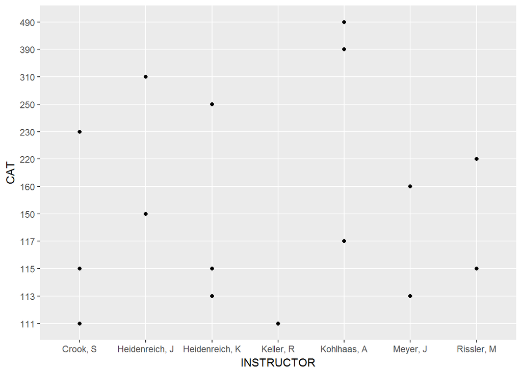

```r
Spring_Schedule %>%

  group_by(DEPT, INSTRUCTOR, CAT) %>%

      filter(!is.na(DEPT) & !is.na(INSTRUCTOR) & !is.na(CAT)) %>%

          filter(DEPT == "L.MAT") %>%

              ggplot() + geom_point(mapping = aes(x = INSTRUCTOR, y = CAT))
```